# ATDS Project

#### Stacked Area Plots

The last plot type in this visualization approach is the stacked area plot, where the count per class for each date is obtained. Two types were created, the normal, with just the counts per day; and a cumulative sum variant, to see the overall evolution is sales.

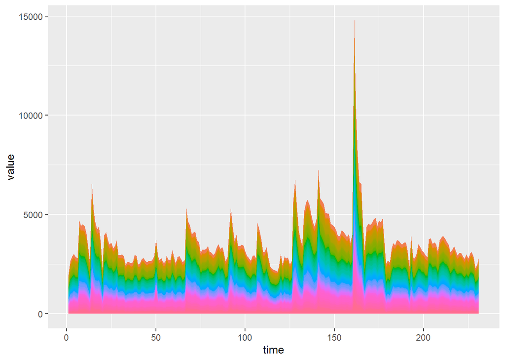

```r
stackedPlot = function(data, timeColumn, targetColumn, legend=FALSE, cumulative=FALSE){
  time <- rep(sort(unique(data[,timeColumn])),each=length(unique(data[,targetColumn])))  # x Axis

  v1 = (data %>% group_by_at(vars(timeColumn,targetColumn)) %>% tally())
  v2 = (data %>% expand(data[timeColumn],data[targetColumn]) %>% group_by_at(vars(timeColumn,targetColumn)))
  value = bind_rows(v1, v2) %>%
    distinct_at(vars(timeColumn, targetColumn), .keep_all = TRUE)  %>%
    arrange_at(vars(timeColumn, targetColumn)) # y Axis
  if (cumulative){
    value = (value %>% group_by_at(targetColumn) %>% arrange_at(timeColumn) %>% mutate(cs = cumsum(n)))$cs %>% replace_na(0)
  } else {
    value = value$n  %>% replace_na(0)
  }
  group = rep(sort(unique(data[,targetColumn])),times=length(unique(data[,timeColumn]))) # group, one shape per group
  plotData = data.frame(time, value, group)
  ggplot(plotData, aes(x=time, y=value, fill=as.character(group))) +
      geom_area(show.legend=legend)
}
stackedPlot(userBrandsDF, "purchase_date", "brand_id", cumulative=FALSE, legend=FALSE)
```

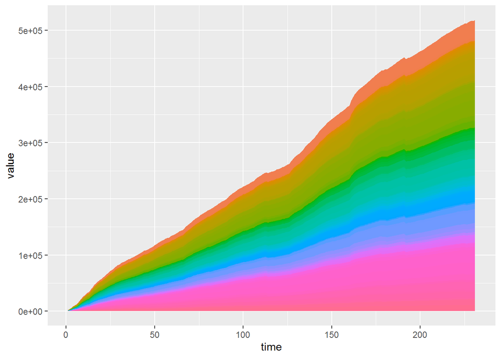

```r
stackedPlot(userBrandsDF, "purchase_date", "brand_id", cumulative=TRUE, legend=FALSE)
```

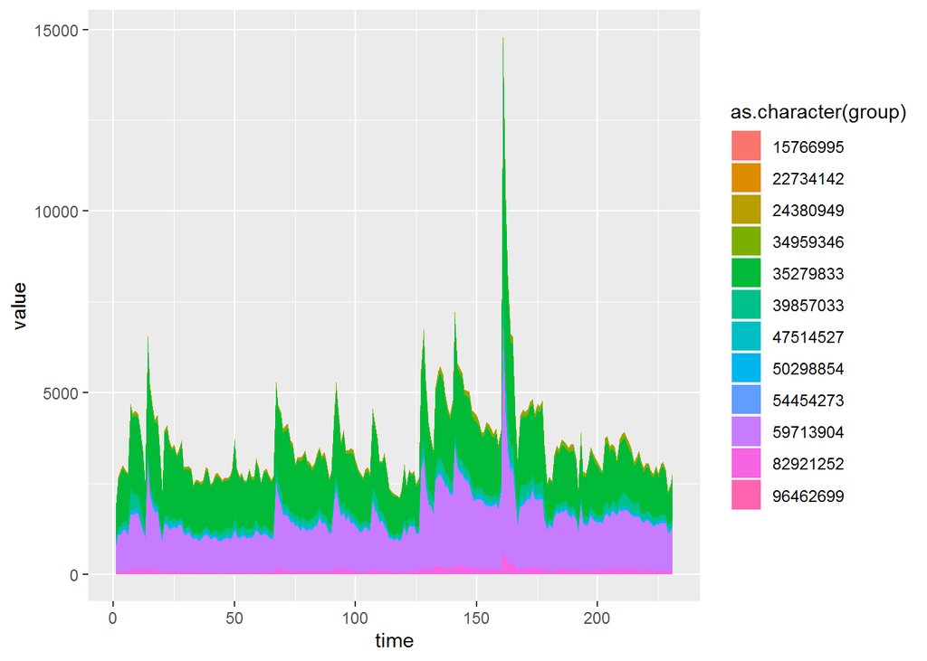

```r
stackedPlot(userBrandsDF, "purchase_date", "platform", cumulative=FALSE, legend=TRUE)
```

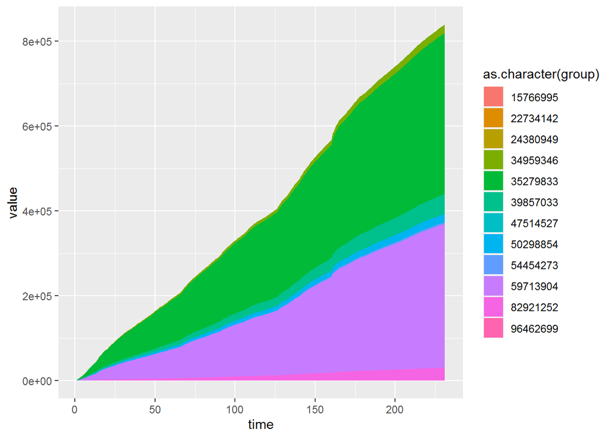

```r
stackedPlot(userBrandsDF, "purchase_date", "platform", cumulative=TRUE, legend=TRUE)
```

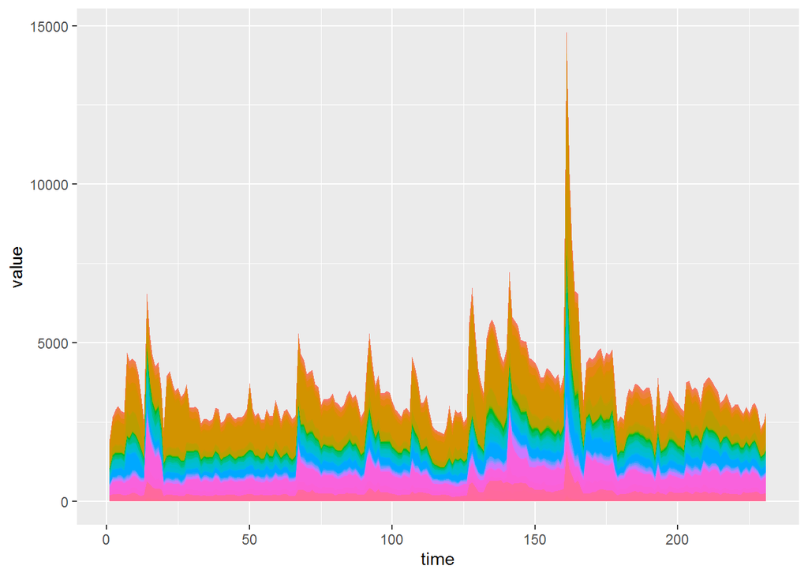

```r
stackedPlot(userBrandsDF, "purchase_date", "country", cumulative=FALSE, legend=FALSE)
```

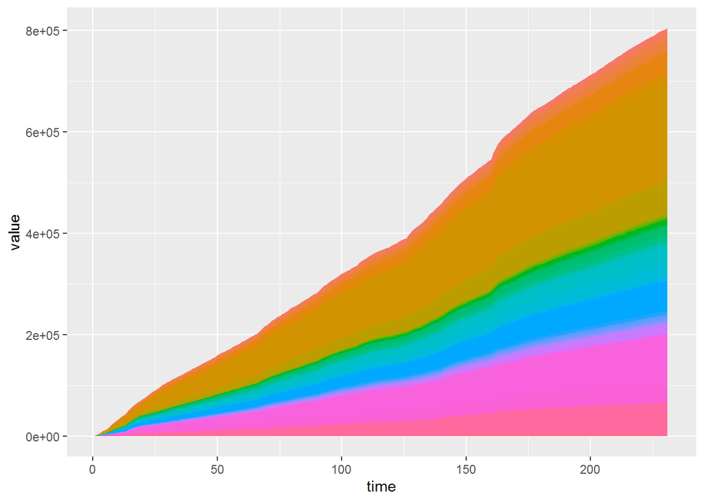

```r
stackedPlot(userBrandsDF, "purchase_date", "country", cumulative=TRUE, legend=FALSE)
```

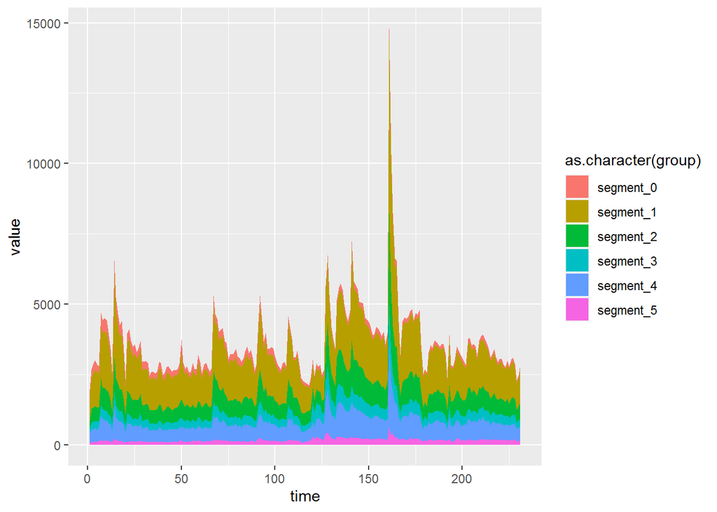

```r
stackedPlot(userBrandsDF, "purchase_date", "user_segment", cumulative=FALSE, legend=TRUE)
```

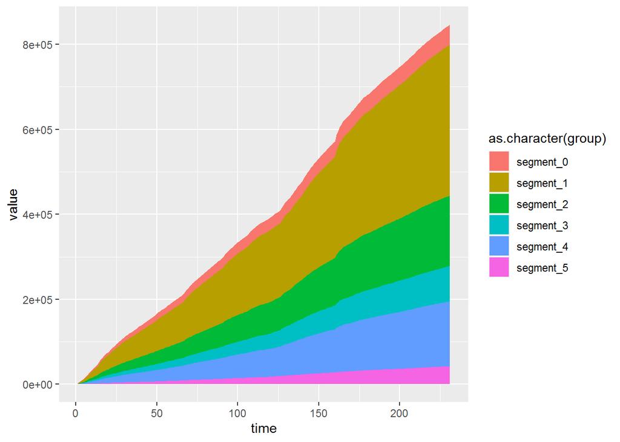

```r
stackedPlot(userBrandsDF, "purchase_date", "user_segment", cumulative=TRUE, legend=TRUE)
```

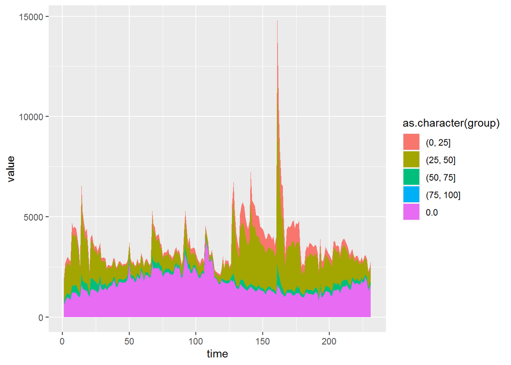

```r
stackedPlot(userBrandsDF, "purchase_date", "perc_sale", cumulative=FALSE, legend=TRUE)
```

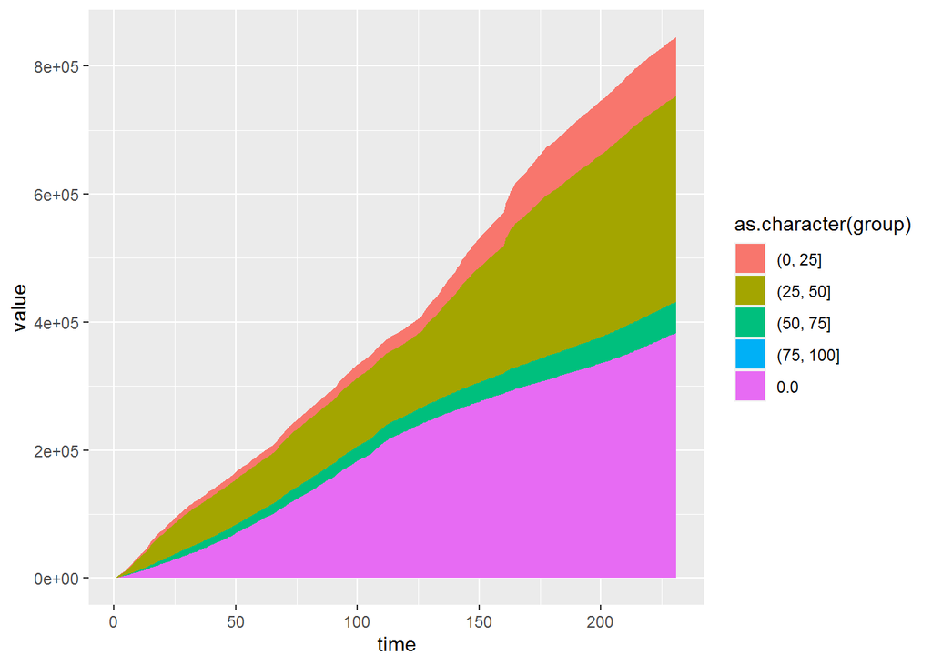

```r
stackedPlot(userBrandsDF, "purchase_date", "perc_sale", cumulative=TRUE, legend=TRUE)
```

The first two plots are those of brand_id. The first thing to note is that the structure of the non-cumulative plot is identical to that of the line plot, with only the colored areas giving further information. However, due to the large number of different classes, it becomes impossible to analyse individual class distributions. Still, these two plots were kept as they were found to be quite pretty.

The second pair of plots, pertaining to the occurrences of platform values, present no clear relation, with values of each class simply increasing proportionally to the overall sales.

The same is repeated for the next two sets of plots, for country and user_segment, again with no clear relation shown.

The last pair, on the other hand, shows a relation between the “(25, 50]” value of perc_sale and time, with a much higher proportion of sales belonging to this class in the latter half of the dates. Other values, however, do not present any strong relation with time.

### Preprocessing

With a thorough data understanding gained by the extensive visualization methodology, some very basic preprocessing followed. This preprocessing simply entails transforming the data from a data frame to a binary ratings matrix and obtaining “recommentderlab” evaluation schemes.

Four schemes were obtained, each using 10-fold cross-validation, with different restrictions on the number of times each user must appear. The minimum numbers of occurrences per user are 1, 2, 5 and 10. Furthermore the goal of predicting the next brand the user will purchase was selected, thus with all but one entry per user being employed as known and the remaining value as unknown.

```r
userBrandsBRM = as(userBrandsDF[c("user_id","brand_id")],"binaryRatingMatrix")

e1 = evaluationScheme(userBrandsBRM, method="cross-validation", k=10, given=-1)

userBrandsBRM2 <- userBrandsBRM[rowCounts(userBrandsBRM)>=2,]
e2 = evaluationScheme(userBrandsBRM2, method="cross-validation", k=10, given=-1)

userBrandsBRM5 <- userBrandsBRM[rowCounts(userBrandsBRM)>=5,]
e5 = evaluationScheme(userBrandsBRM5, method="cross-validation", k=10, given=-1)

userBrandsBRM10 <- userBrandsBRM[rowCounts(userBrandsBRM)>=10,]
e10 = evaluationScheme(userBrandsBRM10, method="cross-validation", k=10, given=-1)
```

# Task 2

The second task of the project entails, as stated in the beginning of this report, the obtention of different recommender systems employing 3 methods, popularity, association rules and collaborative filtering; and the analysis of their respective results resorting to ROC and precision-recall curves.

## Popularity

The recommender that was first developed is the simplest one, using popularity. This recommender works by simply finding which brands occur more often, and then predicting, while removing already seen brands, the N most common. For an example, let’s take the 6 first users as training data and the 7th as test. Bellow we can see the table containing the number brand of occurrences for the 6 users. It is possible to see that in this case all values are equally common. If we intend to predict 2 values, then for the 7th user 2 of these values would be obtained as predictions. Which in this case would be incorrect, as none of these are in this user’s data.

```r
colCounts(userBrandsBRM[1:6,])[colCounts(userBrandsBRM[1:6,]) != 0]
```

```
## 26493521 26715155 33008187 36189858 45417945 51404770 55675036 63020180
##        1        1        1        1        1        1        1        1
## 70512514 78369697 86469062
##        1        1        1
```

```r
modelPop = Recommender(userBrandsBRM[1:6,],"POPULAR")
recsPop = predict(modelPop, userBrandsBRM[7,], n=2)

inspect(getRatingMatrix(userBrandsBRM[7,]))
```

```
##     items
## [1] {19686531,47093199,67196564}
```

```r
as.integer(getList(recsPop)[[1]])
```

```
## [1] 70512514 26715155
```

Given this, the final results, for which all 4 of the evaluation schemes are used, were obtained. The precision-recall and ROC curves, for the top-N values in (1,2,6), can be seen below.

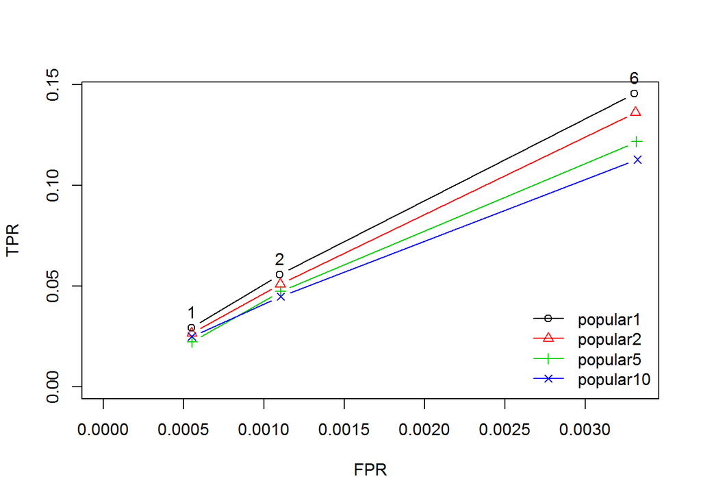

```r
results = evaluate(e10, list())
methods <- list(
  "popular" = list(name="POPULAR", param = NULL)
)
results$popular1 = evaluate(e1, methods, type="topNList", n=c(1,2,6), progress=FALSE)$popular
results$popular2 = evaluate(e2, methods, type="topNList", n=c(1,2,6), progress=FALSE)$popular
results$popular5 = evaluate(e5, methods, type="topNList", n=c(1,2,6), progress=FALSE)$popular
results$popular10 = evaluate(e10, methods, type="topNList", n=c(1,2,6), progress=FALSE)$popular

plot(results,annotate=TRUE)
```

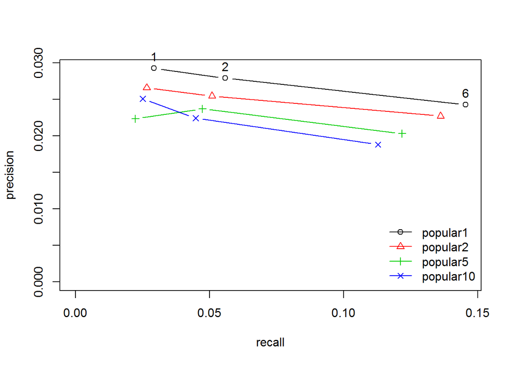

```r
plot(results, "prec/rec", annotate=TRUE)
```

By utilizing these rules for the popular1 curve, N of 1 is selected as the best for the ROC, while the value N of 6 is selected for the precision-recall. Despite popular1’s results being objectively the best, as some of the methods that will be later analyzed cannot use the full dataset, and in fact, a set smaller than that used for the popular10 is not feasible for a fair model comparison, only popular10 will be kept in the curve set.

## Association Rules

The second recommender is that obtained from association rules. This method is far more complex than the previous one and requires some tunning of hyperparameters. This method works by finding the sets of brands that users tend to buy together and create rules indicating their relations. For example, users who buy brand 1 might commonly also buy brand 2, so a rule “brand_1 => brand_2” might be generated. The capability to find popular brands also exists, creating rules such as “ => brand_3”, where brand 3 is predicted regardless of the other brands a user has purchased.

Lets once again see an example using the same 7 users as before, with user 7 being used for testing. Below the set of transactions and rules obtained by the apriori algorithm is presented. Then, passing all but one of the items from user 7 the 2 most likely brands are predicted. The brands are selected in order by the confidence of applicable rules, with rules that are not applicable, obviously being ignored. Unfortunately, none of the rules generated from the 6 users is applicable to the 7th one, and as such, no brand is predicted.

```r
inspect(getRatingMatrix(userBrandsBRM[1:6,]))
```

```
##     items
## [1] {70512514}
## [2] {63020180}
## [3] {26493521,26715155,86469062}
## [4] {33008187,45417945}
## [5] {78369697}
## [6] {36189858,51404770,55675036}
```

```r
modelAr = Recommender(userBrandsBRM[1:6,], "AR", parameter=list(support=0, confidence=0))
rules = getModel(modelAr)$rule_base
inspect(head(rules))
```

```
##     lhs           rhs        support   confidence coverage  lift count
## [1] {33008187} => {45417945} 0.1666667 1          0.1666667 6    1
## [2] {45417945} => {33008187} 0.1666667 1          0.1666667 6    1
## [3] {26493521} => {26715155} 0.1666667 1          0.1666667 6    1
## [4] {26715155} => {26493521} 0.1666667 1          0.1666667 6    1
## [5] {26493521} => {86469062} 0.1666667 1          0.1666667 6    1
## [6] {86469062} => {26493521} 0.1666667 1          0.1666667 6    1
```

```r
recsAR = predict(modelAr, userBrandsBRM[7,], n=2)

inspect(getRatingMatrix(userBrandsBRM[7,]))
```

```
##     items
## [1] {19686531,47093199,67196564}
```

```r
as.integer(getList(recsAR)[[1]])
```

```
## integer(0)
```

The values of support and confidence are the most important and after some search the values of 0.002 for support and 0.2 for confidence were found to perform the best. Bellow the precision-recall and ROC curves can be seen for the same set of top N predictions.

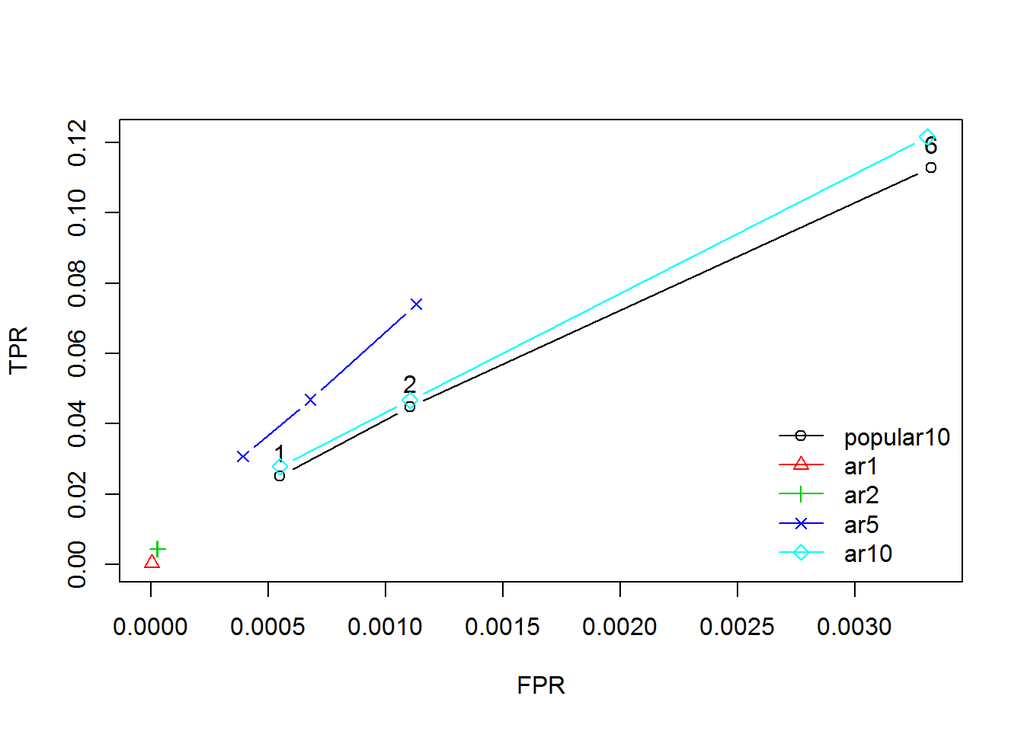

```r
results$popular1 = NULL
results$popular2 = NULL
results$popular5 = NULL

methods <- list(
  "ar" = list(name="AR", parameter=list(support=0.002, confidence=0.2))
)
results$ar1 = evaluate(e1, methods, type="topNList", n=c(1,2,6), progress=FALSE)$ar
results$ar2 = evaluate(e2, methods, type="topNList", n=c(1,2,6), progress=FALSE)$ar
results$ar5 = evaluate(e5, methods, type="topNList", n=c(1,2,6), progress=FALSE)$ar
results$ar10 = evaluate(e10, methods, type="topNList", n=c(1,2,6), progress=FALSE)$ar

plot(results,annotate=TRUE)
```

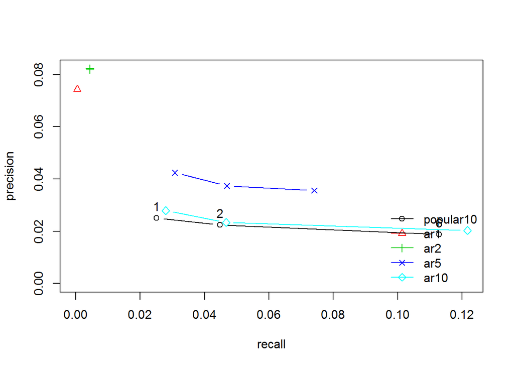

```r
plot(results, "prec/rec", annotate=TRUE)
```

Upon an initial look at the ROC curve, it becomes obvious that something is not as it would be expected, with the ar1 and ar2 curves collapsing into a single point and even the ar5 being shorter than what has previously been observed. An understanding of how FPR is calculated indicates that for a N only slightly bigger than 1, all curves, regardless of performance, should present very similar values. This is not observed, and by knowing how association rules work, this leads to the conclusion that in some instances, or even the majority for ar1 and ar2, not enough rules are generated to obtain the requested top-N predictions. This is, of course, caused by the selected support and confidence thresholds. Despite a lot of effort, it was not possible to find more lax values without making the computational time unreasonably long, and thus, these results are something that will have to be accepted.

For the same reasons as those presented for the popular models, only ar10 will be used henceforth in any of the comparison plots.

## Collaborative Filtering

The last recommender system to be created in task 2 employs collaborative filtering. There are two important variants to this method, user-based and item-based, with both being tested. User-based collaborative filtering works by finding the similarity between users in terms of the items that were purchased, while item-based collaborative filtering selects new items by finding the similarity between different items.

```r
modelUBCF = Recommender(userBrandsBRM[1:6,], "UBCF", parameter=list(method="cosine",nn=2))
modelIBCF = Recommender(userBrandsBRM[1:6,], "IBCF", parameter=list(method="cosine",k=2))

recsUBCF = predict(modelUBCF, userBrandsBRM[7,], n=2)
recsIBCF = predict(modelUBCF, userBrandsBRM[7,], n=2)

inspect(getRatingMatrix(userBrandsBRM[7,]))
```

```
##     items
## [1] {19686531,47093199,67196564}
```

```r
as.integer(getList(recsUBCF)[[1]])
```

```
## [1] 63020180 70512514
```

```r
as.integer(getList(recsIBCF)[[1]])
```

```
## [1] 63020180 70512514
```

Unlike for the previous methods, not all evaluation schemes were possible to use as with the two largest ones there were memory limitations. As such, only the schemes where users appear more than 5 and 10 times were used. For a fair comparison, the same top-N set was employed, and the obtained performance curves are presented below.

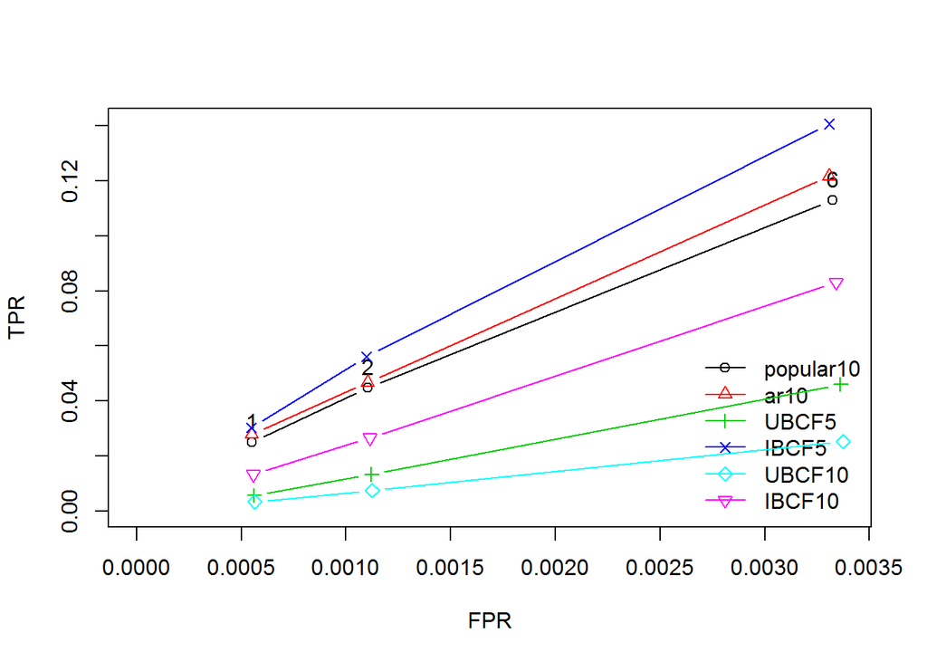

```r
results$ar1 = NULL
results$ar2 = NULL
results$ar5 = NULL

methods <- list(
"UBCF" = list(name="UBCF", param = NULL),
"IBCF" = list(name="IBCF", param = NULL)
)
colabFilter = evaluate(e5, methods, type="topNList", n=c(1,2,6), progress=FALSE)
results$UBCF5 = colabFilter$UBCF
results$IBCF5 = colabFilter$IBCF
colabFilter = evaluate(e10, methods, type="topNList", n=c(1,2,6), progress=FALSE)
results$UBCF10 = colabFilter$UBCF
results$IBCF10 = colabFilter$IBCF

plot(results,annotate=TRUE)
```

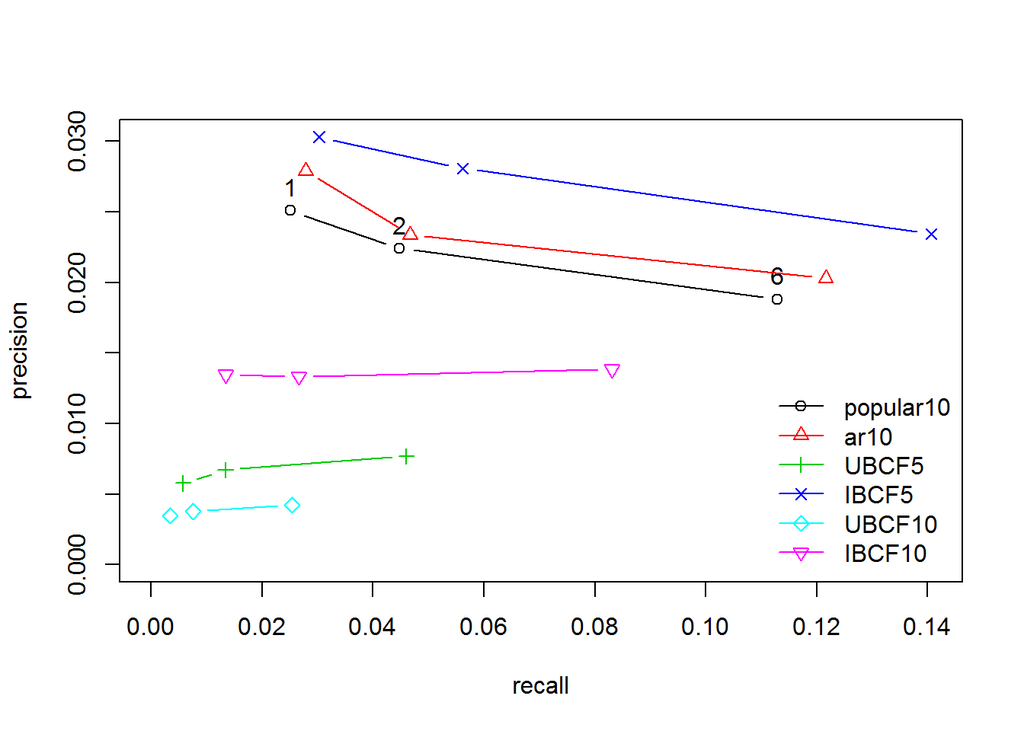

```r
plot(results, "prec/rec", annotate=TRUE)
```

This set of results presents similar findings to those for the set of popular models, with larger datasets leading to improved performance in all instances. Another fact that is clear is the superiority (in this case) of the item-based collaborative filtering over the user-based one, with the former achieving undeniably better results. One thing of note is that for the UBCF5 precision-recall curve, precision improves with N, which indicates that the later predictions are far more accurate.

# Task 3

The final task involves the utilization of the contextual information present in the dataset to improve results. With this goal, an ambitious method employing an LSTM was selected. Due to the complexity of this strategy many decisions had to be made and parameters to be tuned. As such, a more in-depth implementation explanation and detailing will be provided.

A LSTM expects, as its input, ordered sequences (typically by time), and as such, the first step was to order the full dataset by purchace_date.

As the sequences of user purchases are not related to amongst different users, other than similarities in the statistical distributions, feeding them to the LSTM in sequence is bound to create spurious relations based on their arbitrary order. With this in mind, the dataset was divided by user into independent sequences of different lengths.

With the aforementioned steps concluded the data is now in its base format, with a list of user sequences. Now, each variable needs to be treated individually to be passed to the model.

Firstly, at this point, user_id no longer holds meaningful information and was removed.

It is the goal to predict brand_id, as such, knowing it for the current step is not realistic, therefore all values were shifted by one. Thus, the model has access to the brand_id in the previous step, and in case there is no previous step, a value of 0 was selected to fill the empty space. Furthermore, the LSTM does not handle categorical variables, and thus, brand_id was encoded using the brand_features dataset, with the previously placed values of 0 being replaced by all 0s with the same length (120) as the encoding. This set of steps encompasses only the input of the brand_id. For the output, the variable was one hot encoded and no shifting occurred.

The variables platform and user_segment were one hot encoded, while purchace_date was left as is (numerical).

Perc_sale presents an interesting case, as much like for brand_id it does not make sense that it would be known before the purchase. Taking this into consideration, it was also shifted. Unlike all other variables for which the values have no relation, this one is obviously ordinal. Therefore, it was encoded between 1 and 5, with 0 being left to fill the lack of value due to shifting.

As country will be handled differently, by passing into an embeding layer, it was label encoded, and as such after this process we were left with 3 different sets of data. The X set with all but the country variable. The X country set, containing only the country. And the Y set, containing only the one hot encoded brand.

```r
shift = function(array, n){
  c(rep(0, n), head(array, -n))
}
get_x = function(data, toShift=c(), toDrop=c()){
  X = list()
  for (entry in names(data)){
    entryData = array(,c(0,0,0))
    for (column in names(data[[entry]])){
      if (column %in% toDrop){
        next()
      }
      temp = data[[entry]][1:(nrow(data[[entry]])-1),column]
      if (column %in% toShift){
        temp = shift(temp,1)
      }
      entryData = tryCatch(
        abind(entryData,array(temp,c(length(temp),1)),along=3),
        error = function(e){
          array(cbind(entryData,temp),c(length(temp),1,1))
        }
      )
    }
    columns = names(data[[entry]])
    dimnames(entryData)[[3]]=as.list(c(columns[!columns %in% toDrop]))
    X = append(X, list(entryData))
    names(X)[length(X)]=entry
  }
  X
}

get_y = function(data, y){
  Y = list()
  entryNames = paste0(y,"_",levels(data[[1]][,y]))
  for (entry in names(data)){
    entryData = data.frame(data[[entry]][2:nrow(data[[entry]]),y])
    dummy = dummyVars(~ .,data = entryData)
    entryDummy = predict(dummy, entryData)
    entryArray = array(entryDummy, c(nrow(entryDummy),1,ncol(entryDummy)))
    dimnames(entryArray)[[3]]=entryNames
    Y[[entry]] = entryArray
  }
  Y
}

split_brand_features = function(brandFeatures){
  featureMap = list()
  for (row in 1:nrow(brandFeatures)){
    rowFeatures = brandFeatures[[ row,"features"]]
    rowBrand = as.character(brandFeatures[[ row,"brand_id"]])
    rowFeatures = gsub('\\[|\\]|\n', '', rowFeatures) %>%
      strsplit(" ") %>%
      unlist() %>%
      as.numeric()
    rowFeatures = rowFeatures[!is.na(rowFeatures)]
    featureMap[[ rowBrand]]=rowFeatures
  }
  featureMap
}

encode_brand_features = function(brands, brandMap){
  encodedBrands = list()
  counter=0
  for (brand in brands){
    counter = counter+1
    brand = as.numeric(brand)
    if (brand == 0){
      encodedBrand = array(0,c(1,1,length(brandMap[[1]])))
    }
    else{
      encodedBrand = array(brandMap[[brand]],c(1,1,length(brandMap[[brand]])))
    }

    encodedBrands[[counter]] = encodedBrand
  }
  encodedBrands = do.call(abind, list(encodedBrands, along=1))
  dimnames(encodedBrands)[[3]] = paste0("brand_",c(1:dim(encodedBrands)[3]))
  encodedBrands
}


set.seed(1)
toShift = c("brand_id","perc_sale")
toDrop = c("user_id","country")

userBrandsDF10 = as.data.frame(userBrandsDF %>% group_by(user_id) %>% filter(n()>=10))
userBrandsDF10$user_id = as.factor(userBrandsDF10$user_id)
userBrandsDF10$brand_id = as.factor(userBrandsDF10$brand_id)
userBrandsDF10$country = as.numeric(factor(userBrandsDF10$country))-1

userBrandsSplit = split(userBrandsDF10, userBrandsDF10$user_id)
userBrandsSplitX = get_x(userBrandsSplit, toShift, toDrop)

toDrop = names(userBrandsSplit[[1]])[names(userBrandsSplit[[1]]) != "country"]
countryX = get_x(userBrandsSplit, c(), toDrop)

Y = get_y(userBrandsSplit, "brand_id")


brandMap = split_brand_features(brandFeatures)
platformLevels = levels(as.factor(userBrandsDF10$platform))
userSegmentLevels = levels(as.factor(userBrandsDF10$user_segment))
X = list()
for (name in names(userBrandsSplitX)){
  user = userBrandsSplitX[[name]]
  encode_brand_features(user[,,"brand_id"], brandMap)
  brandEncodedUser = abind(user, encode_brand_features(user[,,"brand_id"], brandMap), along=3)
  columns = dimnames(brandEncodedUser)[[3]]
  columns = columns["brand_id" != columns]
  brandEncodedUser = array(brandEncodedUser[,,columns],c(dim(brandEncodedUser)[1:2],dim(brandEncodedUser)[3]-1))
  dimnames(brandEncodedUser)[[3]] = columns


  userSegmentValues = factor(brandEncodedUser[,,"user_segment"], levels=userSegmentLevels)
  userSegmentDF = data.frame(userSegmentValues)
  userSegmentHot = predict(dummyVars(~ userSegmentValues, data = userSegmentDF),userSegmentDF)
  userSegmentArray = array(userSegmentHot,c(nrow(userSegmentHot),1,ncol(userSegmentHot)))
  dimnames(userSegmentArray)[[3]]=userSegmentLevels
  oneHotSegment = abind(brandEncodedUser, userSegmentArray, along=3)

  columns = dimnames(oneHotSegment)[[3]]
  columns = columns["user_segment" != columns]
  oneHotSegment = array(oneHotSegment[,,columns],c(dim(oneHotSegment)[1:2],dim(oneHotSegment)[3]-1))
  dimnames(oneHotSegment)[[3]] = columns


  platformValues = factor(oneHotSegment[,,"platform"], levels=platformLevels)
  platformDF = data.frame(platformValues)
  platformHot = predict(dummyVars(~ platformValues, data = platformDF),platformDF)
  platformArray = array(platformHot,c(nrow(platformHot),1,ncol(platformHot)))
  dimnames(platformArray)[[3]]=paste0("platform_",platformLevels)
  oneHotPlatform = abind(oneHotSegment, platformArray, along=3)

  columns = dimnames(oneHotPlatform)[[3]]
  columns = columns["platform" != columns]
  oneHotPlatform = array(oneHotPlatform[,,columns],c(dim(oneHotPlatform)[1:2],dim(oneHotPlatform)[3]-1))
  dimnames(oneHotPlatform)[[3]] = columns


  oneHotPlatform[,,"perc_sale"][oneHotPlatform[,,"perc_sale"] == "0.0"] = 1
  oneHotPlatform[,,"perc_sale"][oneHotPlatform[,,"perc_sale"] == "(0, 25]"] = 2
  oneHotPlatform[,,"perc_sale"][oneHotPlatform[,,"perc_sale"] == "(25, 50]"] = 3
  oneHotPlatform[,,"perc_sale"][oneHotPlatform[,,"perc_sale"] == "(50, 75]"] = 4
  oneHotPlatform[,,"perc_sale"][oneHotPlatform[,,"perc_sale"] == "(75, 100]"] = 5

  X[[name]] = oneHotPlatform
  class(X[[name]]) = "numeric"
}

for (name in names(countryX)){
  countryX[[name]] = array(countryX[[name]], c(dim(countryX[[name]])[1],1))
}
```

Due to time and computational limitations, it was not feasible to test a large number of model topologies, and as such, the model was left at the bare minimal for our intent. It consists of 2 input layers, the first of which takes the X set and directly passes it to the LSTM layer. The other takes the X country set, passes it first by an embedding layer and then to the LSTM. There is a single LSTM layer, directly followed by a dense output layer with a softmax activation.

One important note for the LSTM layer is that the parameter stateful is set to FALSE, thus resetting its internal state (memory not weights) at each fit or prediction operation, thus ensuring that each sequence is treated independently.

```r
build_model = function(){
  mainInput = layer_input(shape = c(1,dim(X[[1]])[3]), name = 'mainInput')

  countryInput = layer_input(shape = c(1), name = 'countryInput')

  countryEmbeding = countryInput %>%
    layer_embedding(input_dim = length(levels(as.factor(userBrandsDF10$country))), output_dim = 1, name ='countryEmbeding')

  lstmLayer = layer_concatenate(c(mainInput, countryEmbeding), name = "fullInput") %>%
    layer_lstm(units = 1, # size of the layer
         return_sequences = TRUE,
         stateful = FALSE, name = "LSTM") %>%
    time_distributed(keras::layer_dense(units = dim(Y[[1]])[3], activation = 'softmax'), name = "output")

  lstmModel = keras_model(
    inputs = c(mainInput, countryInput),
    outputs = c(lstmLayer)
  )

  lstmModel %>%
      compile(loss = 'categorical_crossentropy', optimizer = 'adam', metrics = c('accuracy'))
  lstmModel
}
```

It is not possible to use the created evaluation schemes for training, but a serious attempt to emulate them as closely as possible was done. First, the data is split into 10 folds. For each fold the model is totally reset (including weights) and the respective data is obtained. Then, for each user, the model is trained on its sequence, resetting memory each time. With the training complete, the predictions are obtained in a similar manner, resetting the memory each time. For consistency with the previous approaches of task 2, although all outputs are used for training, only the last is saved for performance comparisons. In the end, the output of this process is a list containing 10 lists; one for each fold. Each of these lists in turn contains another list for each user. Finally, each of these contains the predicted class indexes in the order of highest predicted value (predicted likelihood).

```r
create_k_folds = function(data, k){
  foldSize = length(data) %/% k
  foldExtra = length(data) %% k
  sampleIndex = 1:length(data)
  folds = list()
  for (fold in 1:k){
    if (foldExtra>=fold){
      folds[[fold]] = sort(sample(sampleIndex, foldSize+1))
    }
    else{
      folds[[fold]] = sort(sample(sampleIndex, foldSize))
    }
    sampleIndex = sampleIndex[!sampleIndex %in% folds[[fold]]]
  }
  folds
}


preds = list()
folds = create_k_folds(X, k = 10)
for (fold in 1:10){
  lstmModel = build_model() # reset model for each fold

  trainX = X[unlist(folds[-fold])]
  trainCountry = countryX[unlist(folds[-fold])]
  trainY = Y[unlist(folds[-fold])]

  validationX = X[unlist(folds[fold])]
  validationCountry = countryX[unlist(folds[fold])]


  for (entry in 1:length(trainX)){
    x = list(trainX[[entry]], trainCountry[[entry]])
    y = trainY[[entry]]
    lstmModel %>% fit(
      x = x,
      y = y,
      batch_size = 1,
      epochs = 1,
      shuffle = FALSE,
      verbose = FALSE,
      view_metrics = FALSE
    )
  }

  predFold = list()
  for (entry in 1:length(validationX)){
    x = list(validationX[[entry]], validationCountry[[entry]])
    pred = predict(lstmModel, x , batch_size=1)
    pred = pred[nrow(pred),,]
    predFold[[entry]] = order(-pred)
  }
  preds[[fold]] = predFold
}
```

The final step in the process is the creation of the precision-recall and ROC curves for the predictions. First the metrics for each user are obtained, then they are averaged per fold, and finally, the results for all folds are averaged.

Before looking at the results it bears mentioning that the parameters for the number of epochs, LSTM layer size and embedding size were tuned, but due to the limited amount of time and lack of access to a TensorFlow compatible GPU (which increased train times over 100X), are far from optimal.

Thus, the best obtained results are presented below.

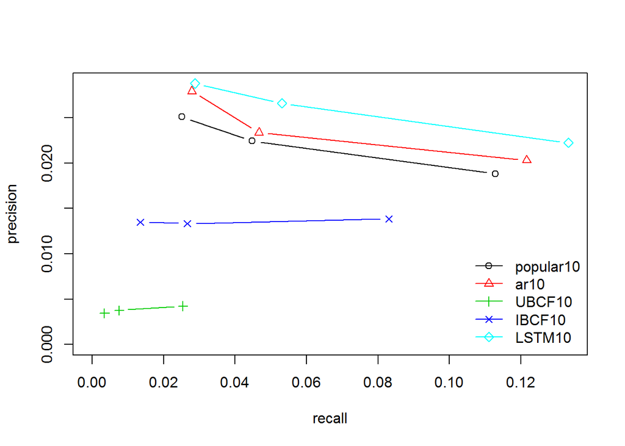

```r
precision_at_n = function(pred, real, N){
  TP = 0
  for (row in 1:nrow(pred)){
    if (real[row] %in% pred[row,1:N]){
      TP = TP +1
    }
  }
  P = nrow(pred)*N
  precision = TP/P
  precision
}
recall_at_n = function(pred, real, N){
  TP = 0
  for (row in 1:nrow(pred)){
    if (real[row] %in% pred[row,1:N]){
      TP = TP +1
    }
  }
  recall = TP/(nrow(pred))
  recall
}
FPR_at_n = function(pred, real, N, factorCount){
  TP = 0
  for (row in 1:nrow(pred)){
    if (real[row] %in% pred[row,1:N]){
      TP = TP + 1
    }
  }
  FPR = (nrow(pred)*N - TP) / (nrow(pred) * factorCount)
  FPR
}


plot_prec_rec = function(results,xlim=c(0,1),ylim=c(0,1)){
  plot(1, type="n", xlab="recall", ylab="precision",xlim=xlim,ylim=ylim)
  legendText=c()
  for (resultIdx in 1:length(results)){
    result = results[[resultIdx]]
    x = result[,"recall"]
    y = result[,"precision"]
    lines(x,y,type="b",pch=resultIdx,col=resultIdx)
    legendText=c(legendText,names(results)[resultIdx])
  }
  legend(
    "bottomright",
    legend=legendText,
    col=1:length(results),
    lty=1,
    pch =1:length(results),
    cex=1,
    bty = "n"
  )
}

plot_ROC = function(results,xlim=c(0,1),ylim=c(0,1)){
  plot(1, type="n", xlab="FPR", ylab="TPR",xlim=xlim,ylim=ylim)
  legendText=c()
  for (resultIdx in 1:length(results)){
    result = results[[resultIdx]]
    x = result[,"FPR"]
    y = result[,"TPR"]
    lines(x,y,type="b",pch=resultIdx,col=resultIdx)
    legendText=c(legendText,names(results)[resultIdx])
  }
  legend(
    "bottomright",
    legend=legendText,
    col=1:length(results),
    lty=1,
    pch =1:length(results),
    cex=1,
    bty = "n"
  )
}

topN = c(1,2,6)
results$UBCF5 = NULL
results$IBCF5 = NULL
results = avg(results)
result = data.frame(row.names = topN)
for (N in topN){
  precision = c()
  recall = c()
  FPR = c()
  for (fold in 1:10){
    pred = do.call(rbind,preds[[fold]])
    testY = Y[unlist(folds[fold])]
    real = c()
    for (user in testY){
      real = c(real, which.max(user[nrow(user),,]))
    }
    precision = c(precision, precision_at_n(pred, real, N))
    recall = c(recall, recall_at_n(pred, real, N))
    FPR = c(FPR, FPR_at_n(pred, real, N, length(levels(as.factor(userBrandsDF$brand_id)))))
  }
  result[as.character(N),"precision"] = mean(precision)
  result[as.character(N),"recall"] = mean(recall)
  result[as.character(N),"TPR"] = mean(recall)
  result[as.character(N),"FPR"] = mean(FPR)
}
results$LSTM10 = result

maxPrecision = 0
maxRecall = 0
maxFPR = 0
for (result in results){
  maxPrecision = max(maxPrecision, max(result[,"precision"]))
  maxRecall = max(maxRecall, max(result[,"recall"]))
  maxFPR = max(maxFPR, max(result[,"FPR"]))
}
plot_prec_rec(results, xlim=c(0,maxRecall), ylim=c(0,maxPrecision))
```

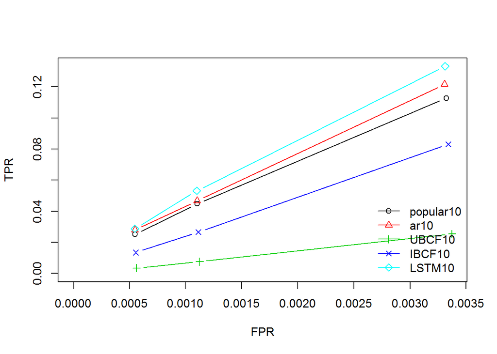

```r
plot_ROC(results, xlim=c(0,maxFPR), ylim=c(0,maxRecall))
```

On the previous ROC and precision-recall curves, it is possible to see that the LSTM algorithm achieves betters results than the second best ar10. Surprisingly, despite some variety of hyperparameters tested, the simplest employing an embedding and LSTM layer sizes of 1, with training being done for a single epoch attained the best results.

# Conclusion

The work performed has many limitations, almost all of which computational in nature. The collaborative filtering models ran into memory limitations with the largest dataset subset, while the LSTM models took too long to train for an extensive combination of model hyperparameters and topologies to be tested, which hindered the results.

The principal avenue for future work lies in the continuation of finetuning the various LSTM parameters. To speed up this process an inheritance from an unknown rich uncle would be welcome, allowing the obtention of a GPU that is compatible with TensorFlow and Keras.